# 10 ggplot 1: plot types (geometries)

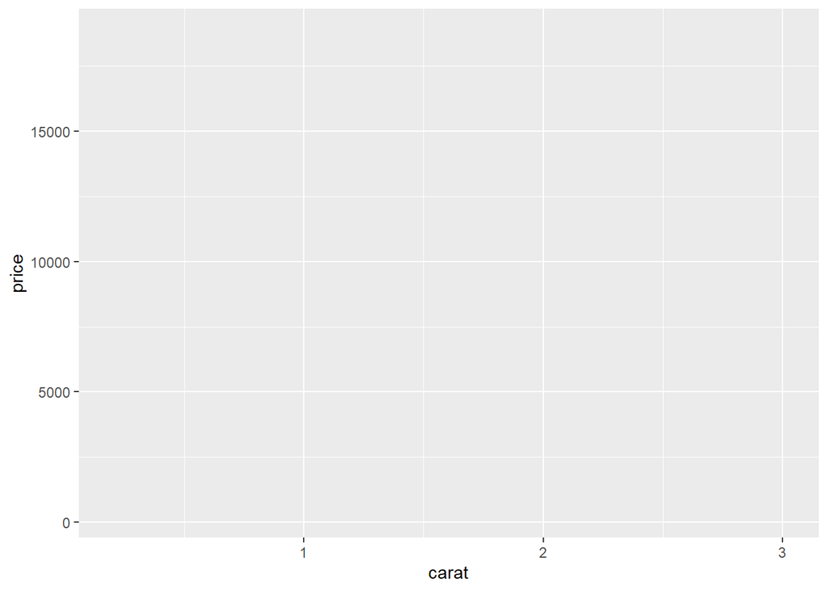

```r
ggplot(dia, aes(x = carat, y = price, color = cut, size = clarity, shape = color))
```

```r
aes(x = carat, y = price, color = cut, size = clarity, shape = color)
```

[output not shown]

You can map the same variable on two ore more aesthetics. For instance, mapping `cut` on size and shape will show every level of `cut` with a different size and a different shape.

## 10.4 Geometry

The first layer includes the data and the aesthetic mappings that will be used for all geometries in the plot (unless another aesthetic is specified). At this stage, we know which variable R will show using which aesthetics. We also know where R will find these variables: in the data frame included in the `data` argument of the `ggplot()` function. We don’t know how these variables will shown. To add this component, we need an additional layer: the one that includes the geometry and the statistics. In other words, we need a plot type. {ggplot2} includes many geometries or types of plots and I refer to the [geometry section](https://ggplot2.tidyverse.org/reference/index.html#geoms) in the {ggplot2} and Chang (2025) or to view all these possibilities. Here, you’ll find the often used geometries: point geometries (e.g. scatter plots), line geometries (a line graph), area geometries, bar and column charts and geometries that summarize the data using e.g. a boxplot or a density.

Note that there are many ways to visualize the same data. The same aesthetics (x- and y-axis, color, fill, line type of width, shape, size or alpha) can be used with many geometries. However, not all geometries allow for the same aesthetics. A point geometry - where you use a “dot” to show combinations of values for the variables mapped on both x- and y-axis - allows you to include color, shape, size of transparency. However width for instance is not relevant. For a bar chart, you can include fill, color, transparency, but shape would be irrelevant.

Second, every geometry is a layer. This allows you to add geometries on top of one another. Doing so, you can add a line geometry to a point geometry or text geometry and build complex data visualizations. Here, we will not focus too much on how you can do so, but once you master the individual geometries, adding additional ones is straightforward.

Usually, you can show the data in numerous ways. To illustrate, here are [100 visualizations] (https://100.datavizproject.com/) of the same dataset: a small table showing the number of World Heritage sites in Denmark, Norway and Sweden for 2004 and 2022. In other words, there are 100 ways to visualize data in a table with 2 rows and 6 columns. Selecting the best geometry to visualize your data is very important. Here are many guides to help you select the appropriate geometry, e.g. [from Data to Viz] (https://www.data-to-viz.com/), [Visual Vocabulary] (https://ft-interactive.github.io/visual-vocabulary/) or the guide from the [UK’s Office for national statistics] (https://service-manual.ons.gov.uk/data-visualisation/chart-types). If you add various geometries as separate layers, you have to think about the order in which they are shown: a line geometry followed by a point geometry will show the points on top of the lines.

#### 10.4.0.1 Point geometries

A point geometry is used to show the correlation between two numeric, continuous variables. The first variable is mapped on the horizontal axis, the second on the vertical axis. These two, `x` and `y`, are required aesthetics. For every observations, a point geometry shows the pair of values for the variable mapped on the x-axis and the variable mapped on the y-axis as a single dot. Note that you shouldn’t interpret “dot” in a literal sense as you can change that representation and use e.g. a cross, … .

##### 10.4.0.1.1 `geom_point()`

Most geometries share a large number of arguments. So, we will discuss this geometry in detail. Doing so, when we introduce other geometries we can focus on those arguments that are particular for a geometry.

###### 10.4.0.1.1.1 The function

The function `geom_point()` includes the following arguments:

```r
geom_point(
  mapping = NULL,
  data = NULL,
  stat = "identity",
  position = "identity",
  ...,
  na.rm = FALSE,
  show.legend = NA,
  inherit.aes = TRUE
)
```

The arguments for `geom_point()` include an aesthetic mapping argument `mapping`, a data argument `data`, a stats argument with default `identity` and a position argument with default `identity`. Recall from Chapter 9 that one of the elements of the grammar of graphics refers to the statistics. Here `stat = "identity"` means that R will plot the values of the series: the “statistics” R plots are identical to the values in the dataset. For other geometries, we’ll see for instance `stat = "count"`. Here, R will not plot the values, but will “count” the number of observations. From `position = "identity"`, you can see that R will also plot the values on their exact location. In other words, a pair (1.5, 2.5) will be shown in the location that corresponds with 1.5 on the horizontal axis and 2.5 on the vertical axis. The exact location is where the line starting in 1.5 on the x-axis and moving up crosses the line starting in 2.5 on the y-axis and moving left. We’ll see other position values, e.g. “jitter”, where R add a random component to both the x and y value, “stack” telling R to “stack” the values onen for one, … .

The value `NULL` for the first two arguments means that R will use the default aesthetic mappings included in the `ggplot(aes())` call. However, you can add the data and aesthetic mapping also in the `geom_point()` function. Doing so, R will use the data and aesthetics in this geometry only. `geom_point()` needs at least two mappings: one on the x- and one on the y-axis. If these mappings are not included in the `ggplot()` call, you have to add them here. However, you can also add other mappings. Recall for instance that we have mapped the total population of a country on the size aesthetic. If you would use the `ggplot()` aesthetic mapping to map variables on the x- and y-axis, you can use the `mapping` argument in this geometry to add additional aesthetics. Doing so, R will only use these aesthetics within `geom_point()`.

The `...` allow to determine the settings of the points, e.g. their color, size or shape. Recall that settings do not reveal any information. While aesthetics are used to show data in the plot, settings are used to change the color, size of shape of a point without revealing any information.

The `stats` argument allows you to define transformations. The default `identity` shows the the data as they are. The `position` argument with default `identity` shows the points as they are in the data: every “dot” is shown in the panel exactly on value pair spot. However in some cases, one point actually masks two ore more points with the same value pair.

Let’s see what these arguments do. We start from `ggplot(data = dia, mapping = aes(x = carat, y = price))` and add the `geom_point()` layer, accepting all defaults:

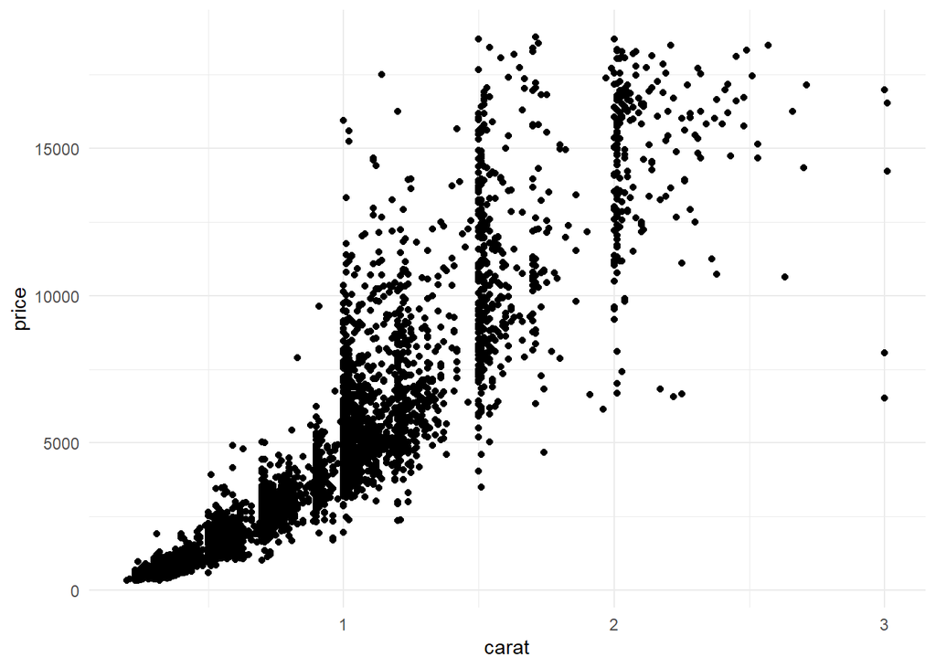

```r
layer1 + geom_point()
```

First note that `ggplot()` doesn’t use the pipe operator to add layers but a `+`. This is because the function `ggplot()` - which was used to create `layer1` - does not return a data frame. As the pipe operator is used to pipe a data set or value in a function and `layer1` is not a value or a data frame, you can not pipe `layer1` in the `geom_point()` function. There is a second argument for the `+`: it shows that `ggplot()` builds a plot by adding one layer on top of the other.

Recall that `layer1` didn’t include the aesthetic mapping on color. In other words, this point geometry only included the aesthetic mappings on the horizontal and vertical axis. By default, R uses black dots to represent each (carat, price) pair. Every dot shows one observation. The shape of the cloud illustrates the correlation between the variable on the horizontal and the one on the vertical axis. In Figure 10.1, there are six patterns shown in six panel. The first panel, shows no correlation. The point cloud does not show any pattern. The second panel include a pattern where the two variables are correlated, but not in a linear way. Using traditional measure for correlation, the result would suggest the absence of any correlation between variable 1 and variable 2. However, as panel 2 reveals: the correlation is actually strong, but not linear. Panels 3 to 6 show clouds that suggest weak positive correlation (panel 3), weak negative correlation (panel 4) and strong positive (panel 5) and negative (panel 6) correlation. These panel all show a point geometry. In other words, using a point geometry allows you to detect a pattern in the correlation between two variables, even if that correlation is not linear.

Figure 10.1: Correlation patterns

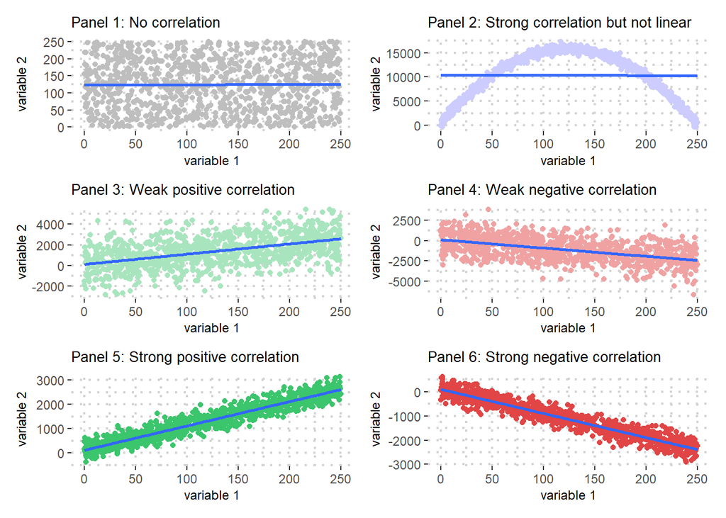

###### 10.4.0.1.1.2 Changing the settings

Before we add additional aesthetic mappings, let’s first review what the options are for changing the settings of this plot. The options for the settings are usually also available for the mappings. Recall that settings don’t add any new information to the plot and only change the way the plot is shown. By default, R shows the dots with a black color. You can change the color of the points into e.g. red. You can do so by adding `color = "red"` to `geom_point()`:

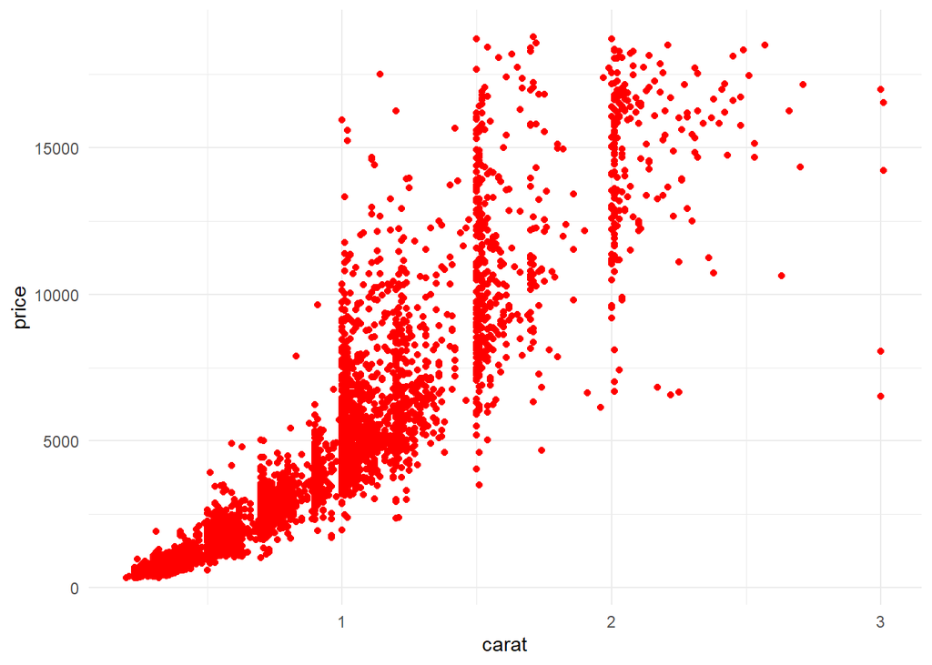

```r
layer1 + geom_point(color = "red")
```

As an alternative, you can use “lightyellow”:

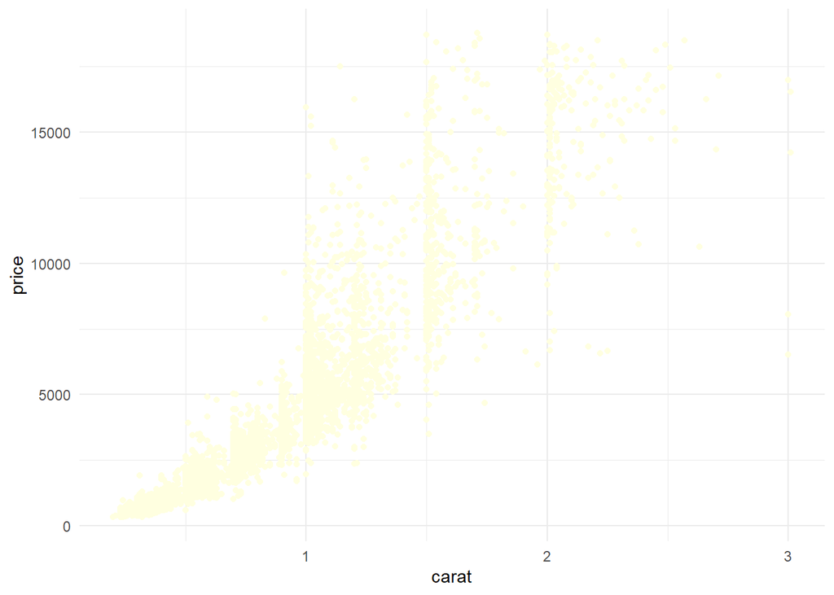

```r
layer1 + geom_point(color = "lightyellow")
```

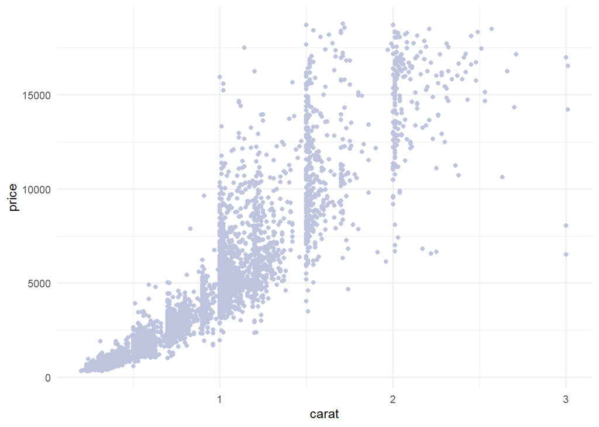

```r
layer1 + geom_point(color = "#BEC4DE")
```

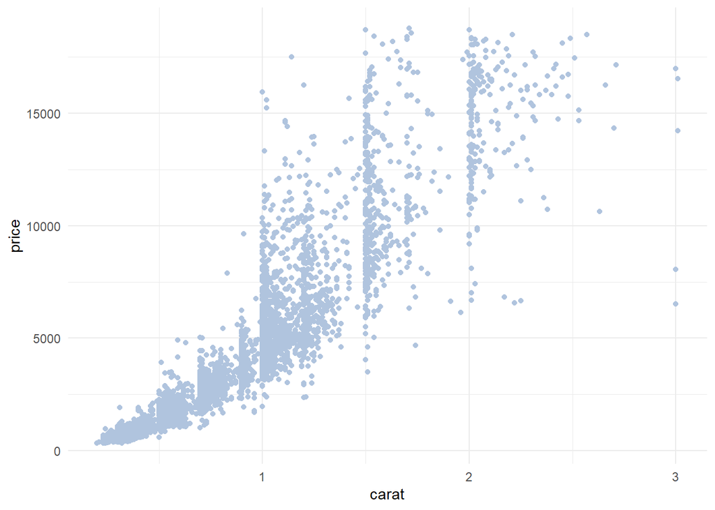

```r
layer1 + geom_point(color = "lightsteelblue")
```

To find a color, you can use online color pickers. These usually allow you to identify a color on a wheel or picture and return various color codes: HEX, RGB, … If you copy paste the HEX code, R will show exactly that color. In addition, most of these color pickers allows you to generate complement colors, shades, … [Here](https://imagecolorpicker.com/) for instance, you can find HEX codes. Using their [detail](https://imagecolorpicker.com/color-code/537acb), you can find complements, … .

Using alpha, you can change the transparency of a point. This value is between 0 (absolute transparency) and 1 (no transparency). To illustrate, using the color red and transparency 1/5:

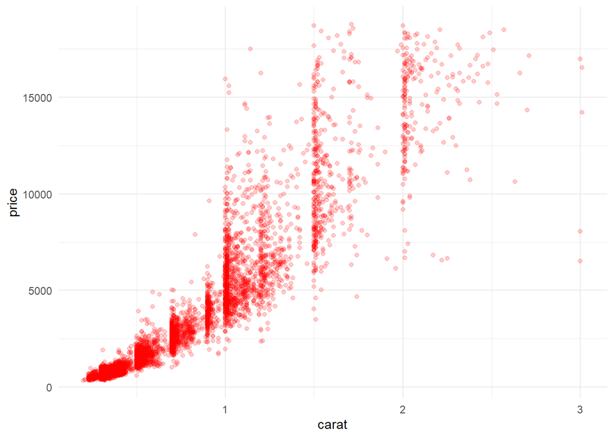

```r
layer1 + geom_point(color = "red", alpha = 1/5)
```

The plot now shows for which values the dataset includes a lot of observations. As these single, transparent, dots overlay, they produce a brighter color. Here, you can see that the dataset includes a lot of observations for diamonds with a lighter weight and lower price.

To adjust the size of the dots, you can use the `size` setting. For instance, setting the size = 5 shows much larger dots:

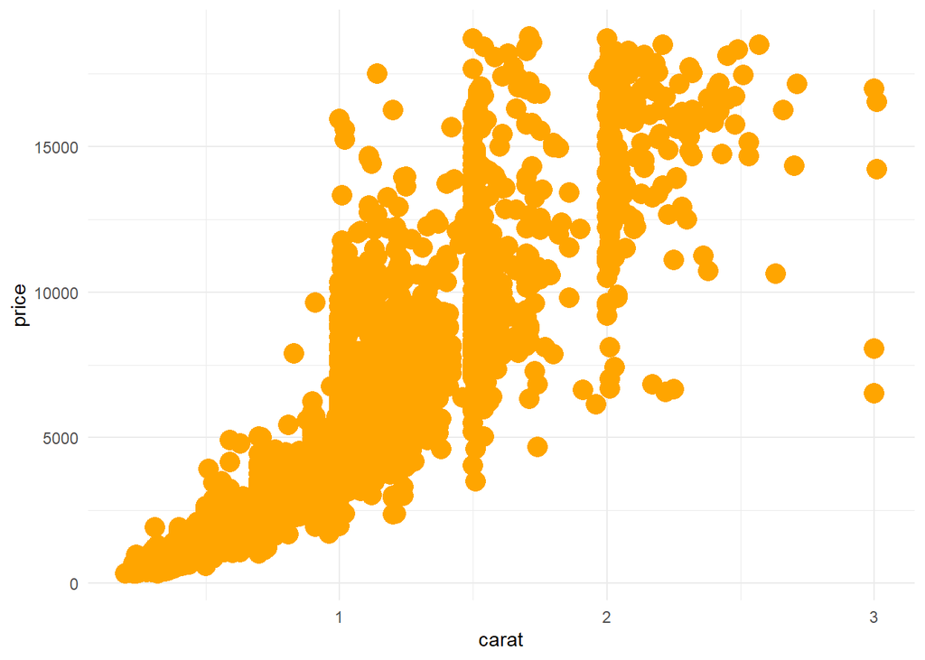

```r
layer1 + geom_point(color = "orange", size = 5)
```

Using size = 0.75 much smaller

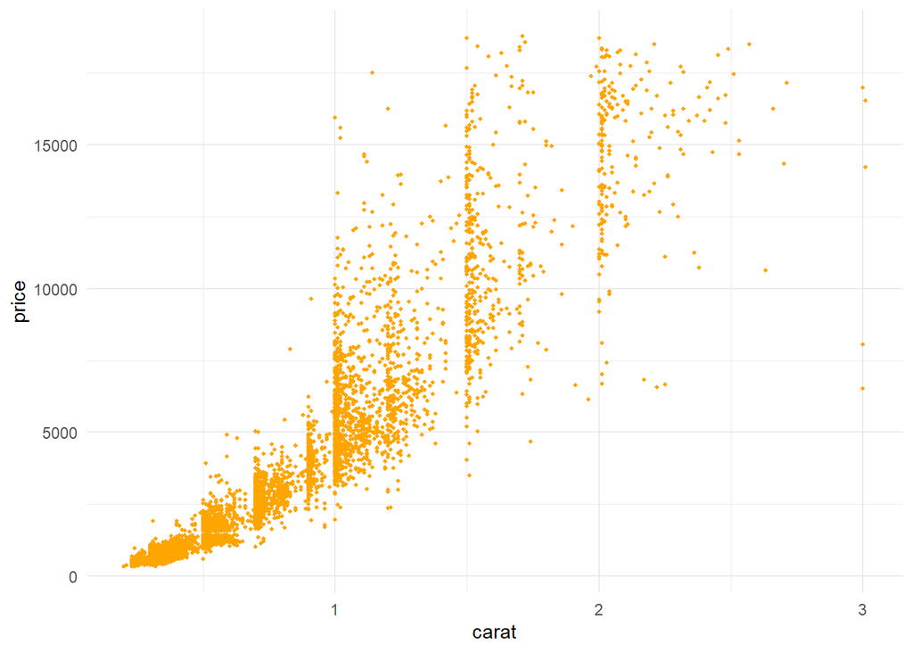

```r
layer1 + geom_point(color = "orange", size = 0.75)
```

In addition to the color and size, you can also change the shape using `shape =`. To identify a shape, you can refer to its number (shown in Figure 10.2) or name (shown in Figure 10.3).

Figure 10.2: Shapes by number

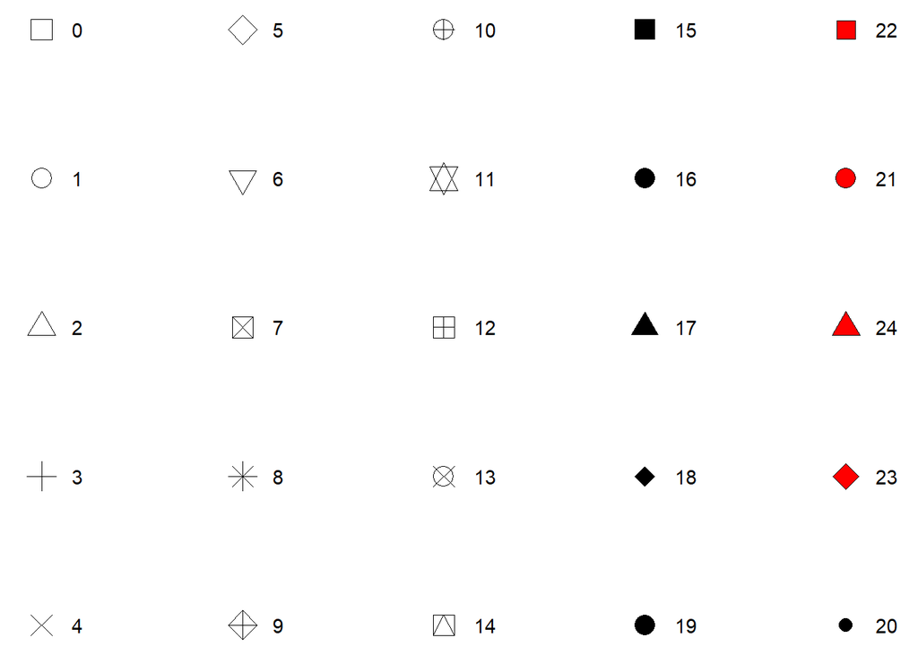

Figure 10.3: Shapes by name

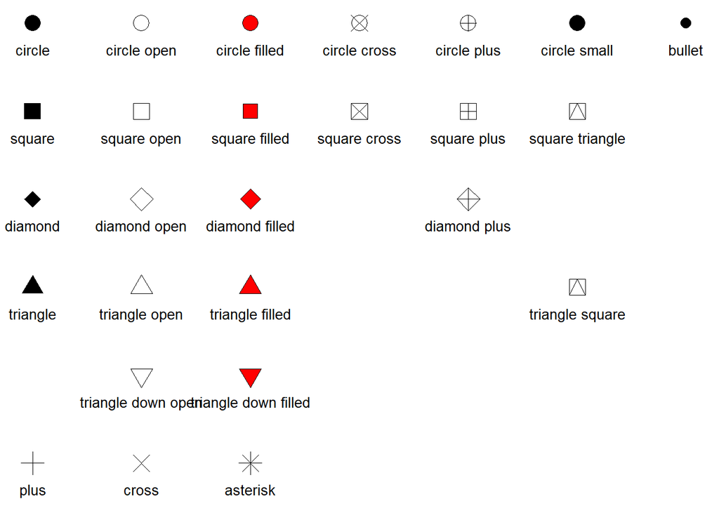

Let’s show the “dots” with a cross (shape 4):

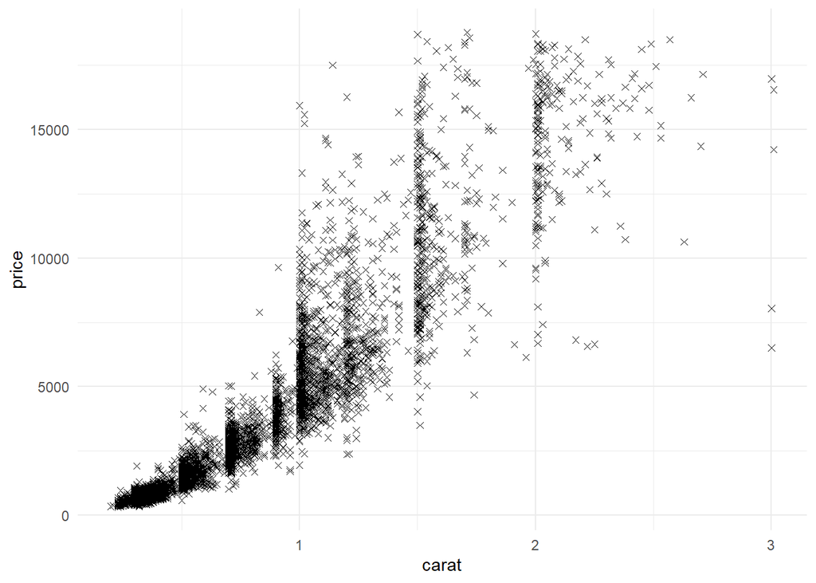

```r
layer1 + geom_point(shape = 4)
```

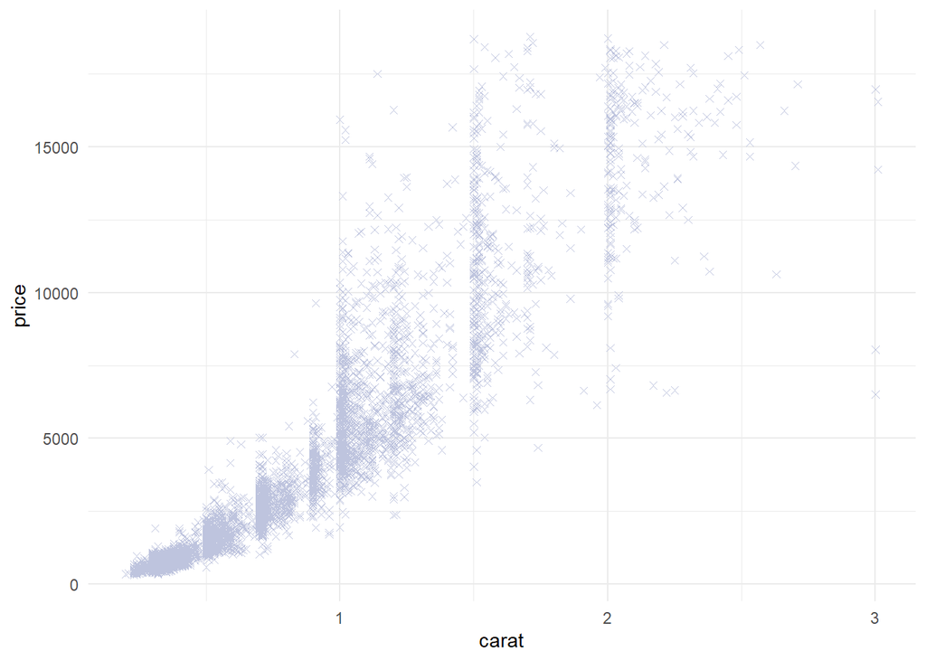

```r
layer1 + geom_point(color = "#BEC4DE", shape = 4)
```

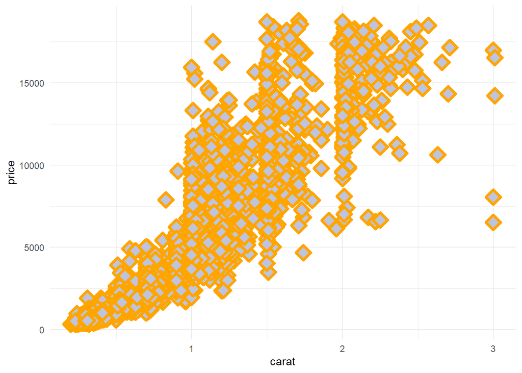

```r
layer1 + geom_point(shape = 23, color = "orange", fill = "#BEC4DE", size = 4, stroke = 2)
```

Figure 10.4: Size and stroke

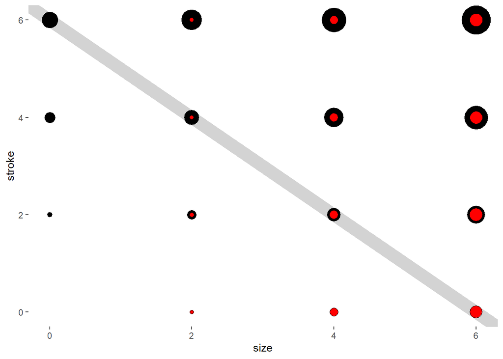

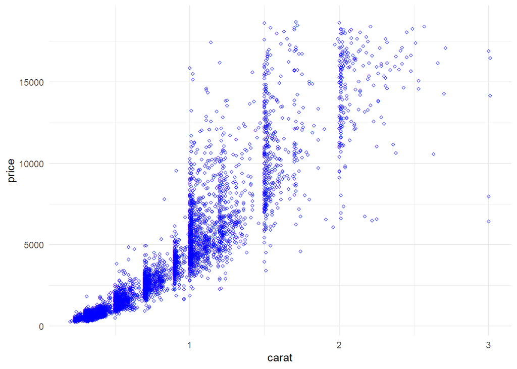

```r
layer1 + geom_point( shape = "\u25C7", color = "blue", size = 2)
```

The list of unicode symbols include math symbols, currency symbols, weather symbols, emoji’s, … .

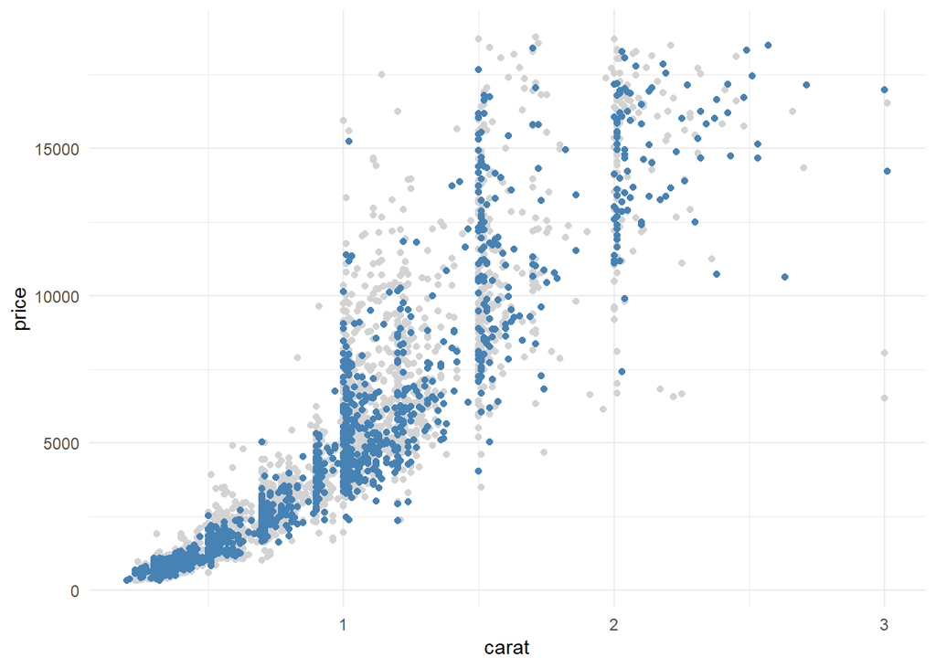

```r
layer1 +
  geom_point(color = "lightgrey") +
  geom_point(data = filter(dia, cut == "Premium"), color = "steelblue")
```

As `ggplot()` builds a plot layer by layer and the second `geom_point()` function is added on top of the first one, the values in this second point geometry will be shown on top of those in the first. As a result, although the plot shows the values for `cut == "Premium"` twice: once in the first and once in the second point geometry, you can see them only once.

As we will see, you can now add an annotation:

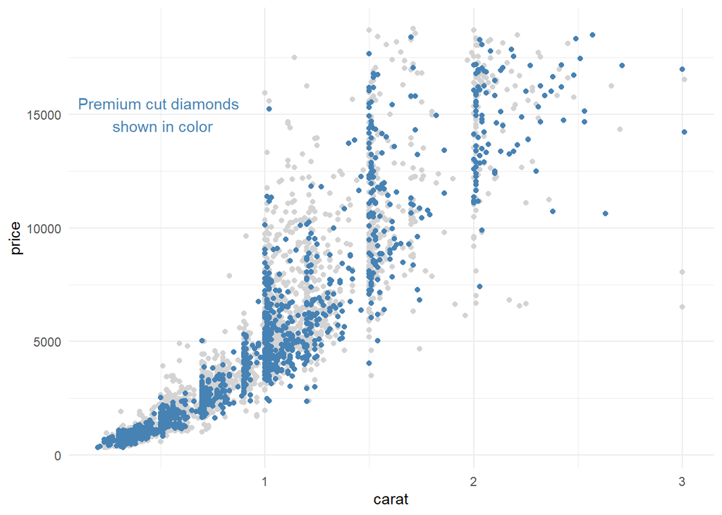

```r
layer1 +
  geom_point(color = "lightgrey") +
  geom_point(data = filter(dia, cut == "Premium"), color = "steelblue") +
  annotate("text", x = 0.5, y = 15000, label = "Premium cut diamonds \n shown in color", color = "steelblue")
```

###### 10.4.0.1.1.3 Aesthetic mappings

Adding aesthetic mappings, in contract to settings, adds values of additional variables, i.e. they extend the information that is shown in the plot. You add these mappings in the `aes()` function. Doing so, `ggplot()` will show different colors, shapes, sizes or strokes for every value of the variable that was mapped on that aesthetic. To illustrate, let’s again start from `layer1` and map the variable cut on the aesthetic color. Recall that the aesthetic mapping in `layer1` mapped carat on the x-axis and price on the y-axis. A geometry inherits these mappings. As a result, we only have to add the new mapping in the geometry mapping argument. For instance, adding `aes(color = cut)` in the `geom_point()` function adds this mapping to the one in `layer1`. Using all other default values for this geometry:

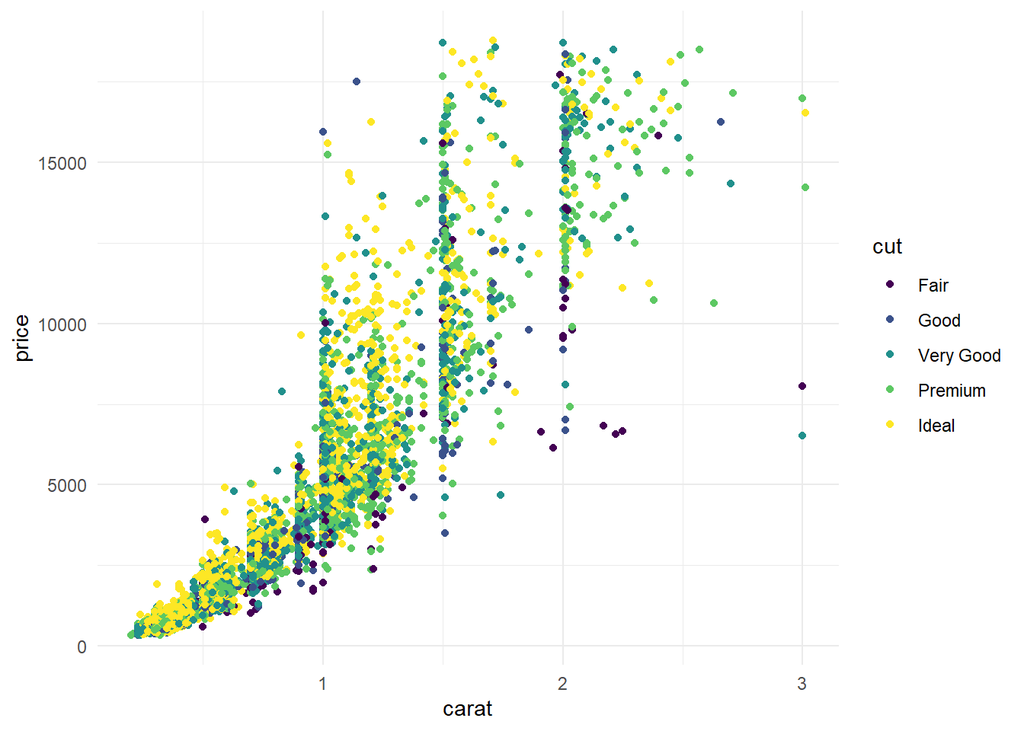

```r
layer1 + geom_point(aes(color = cut))
```

This plot could have been made using

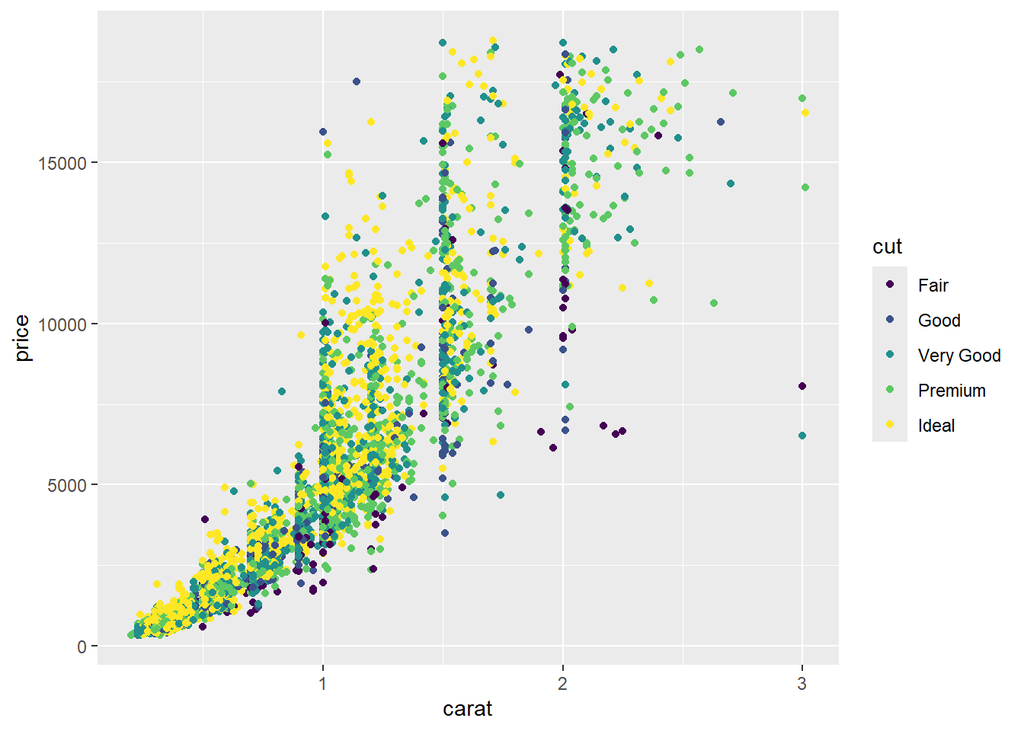

```r
dia |> ggplot(aes(x = carat, y = price, color = cut)) +
  geom_point()
```

or

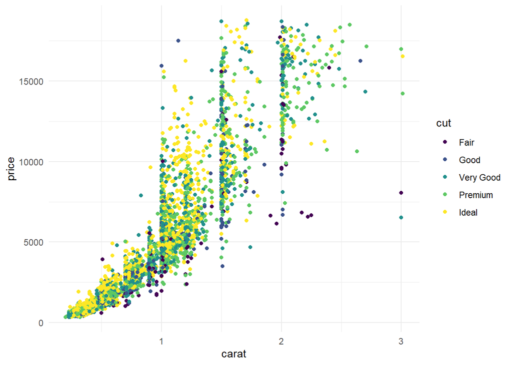

```r
ggplot(dia) +
  geom_point(aes(x = carat, y = price, color = cut)) +
  theme_minimal()
```

The result now shows different colors per level of `cut`. Using the guide (or legend), you can see that diamonds whose cut is `ideal` are shown with a yellow dot, `premium` with a light green dot, … . By default, R adds this guide or legend. Adding `show.legend = FALSE` would remove that legend. However, in that case, it would be difficult to interpret the color scale. Note how the plot shows each aesthetic mapping: the variable that was mapped on the horizontal axis is shown as a label under that axis, the variable that was mapped on the vertical axis is shown as a label with the vertical axis and the variable that was mapped on the color aesthetic is shown in the legend.

What if you add aesthetic mapping on color as well as set a setting for color? In that case, R overrides the aesthetic mapping and shows all colors in the color defined in the setting. For instance:

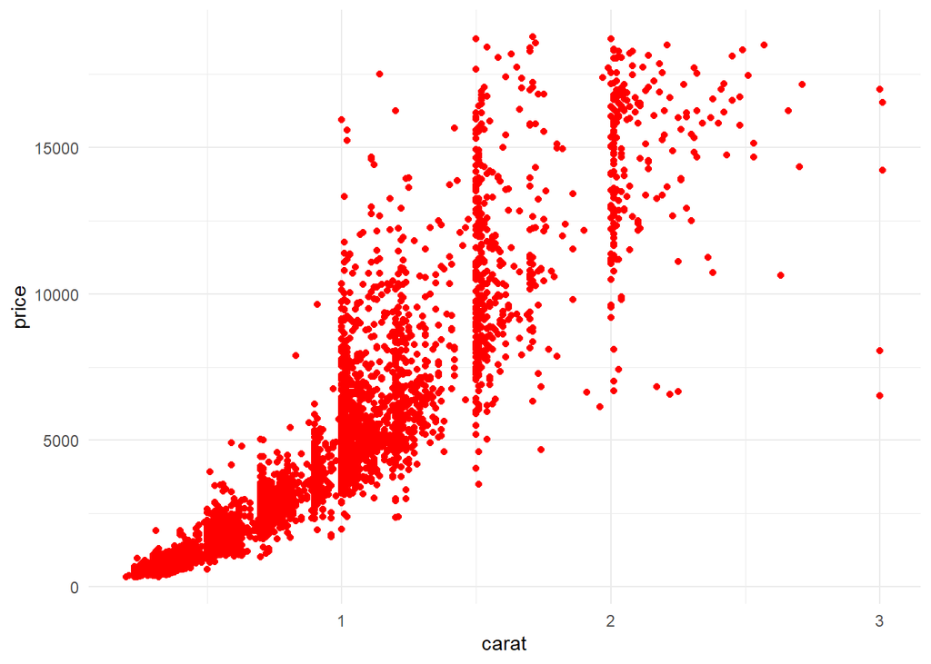

```r
layer1 + geom_point(aes(color = cut), color = "red")
```

In the result, you can see that R shows all dots in red. In addition, it removes the legend. You can however, specify other settings, e.g. if you map cut on the aesthetic color, you can still change the setting shape. R will now show every point using the same shape and will use various colors to show the values of the variable `cut`:

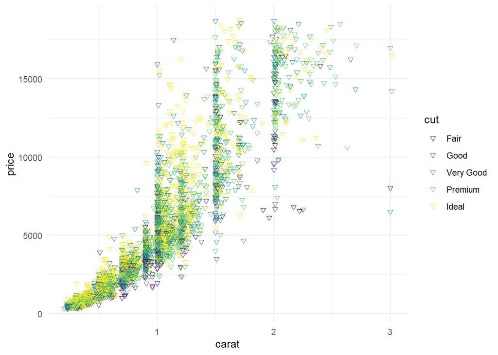

```r
layer1 + geom_point(aes(color = cut), shape = 6)
```

Here, R maps the variable `cut` on the aesthetic color and shows the “dots” using a triangle.

In addition to the color aesthetic, `geom_point()` also accepts the fill, shape, size and stroke aesthetic. In addition, you can include more mappings in the `aes()` function. To illustrate. Let’s add another aesthetic mapping and map the variable in the diamonds dataset `color` (not to be confused with the aesthetic in R, the variable and aesthetic both happen to have the same name) on the shape aesthetic:

```
Warning: Using shapes for an ordinal variable is not advised
```

```
Warning: The shape palette can deal with a maximum of 6 discrete values because more
than 6 becomes difficult to discriminate
ℹ you have requested 7 values. Consider specifying shapes manually if you need
  that many of them.
```

```
Warning: Removed 284 rows containing missing values or values outside the scale range
(`geom_point()`).
```

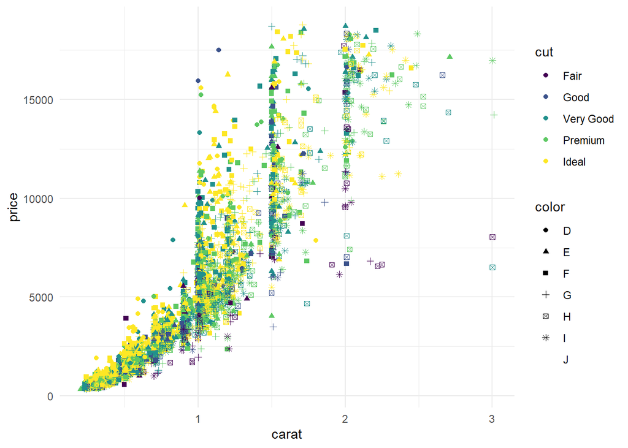

```r
layer1 + geom_point(aes(color = cut, shape = color))
```

Here, R produces a warning: the shape palette can deal with a maximum of 6 discrete values and more than 6 become difficult to differentiate. If you look at the legend, you’ll see that R didn’t include the shape for color “J”. In this case, you could change the mapping and map `cut` one shape and `color` on the aesthetic color:

```
Warning: Using shapes for an ordinal variable is not advised
```

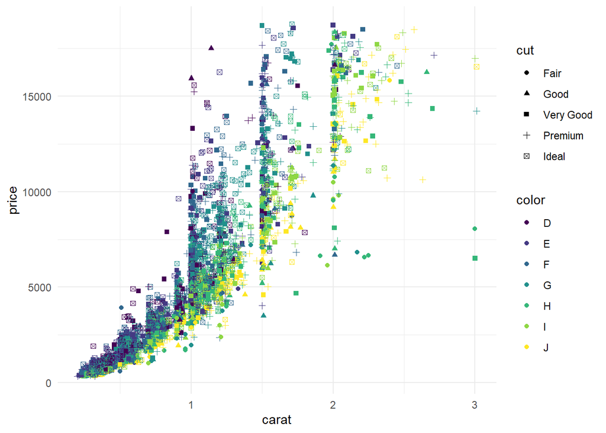

```r
layer1 + geom_point(aes(color = color, shape = cut))
```

However, here too, R shows a warning. What R is essentially telling here is that you are mapping an ordinal variable on a aesthetic that doesn’t allow to show something in an ordered way: a cross is not better or worse than a dot. For ordinal variables, it is better to use another aesthetic that does allow to show the order. Color for instance, can be shown from light to dark and reflect in order in that way. The same holds for size: a better “cut” can be shown with a larger or smaller size. For instance, if you map `color` on size:

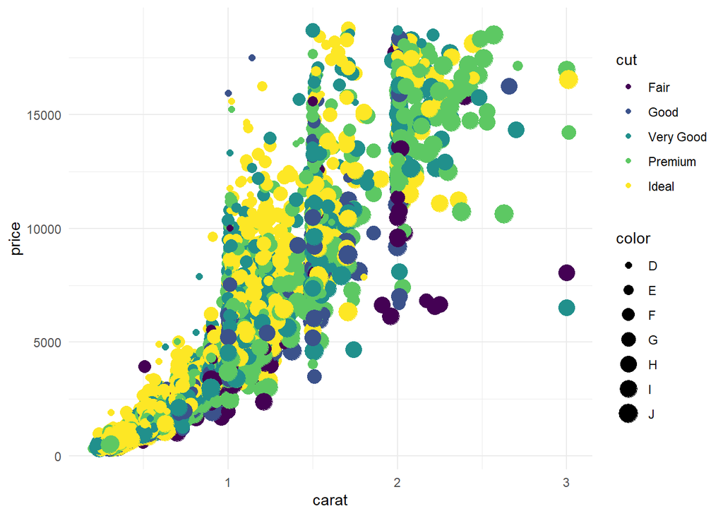

```r
layer1 + geom_point(aes(color = cut, size = color))
```

the plot shows `color` “D” using the smallest dot while “J” is shown using the largest dot. The shape aesthetic allows you to map nominal values. Here, the order is not relevant can R can show these values with different shapes. However, R will restrict the number of nominal values to 6.

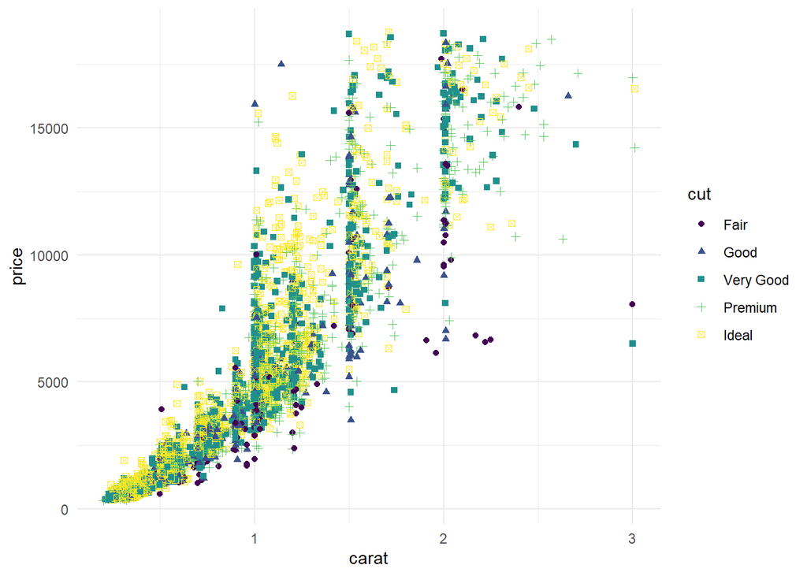

```r
layer1 + geom_point(aes(color = cut, shape = cut))
```

In Chapter 11, we see how you can change the colors, size and shape … in the mapping and show them in the color of your choice and not in the default color values.